# Linegraphs Learning Checks

Albert Y. Kim

Wed Sep 28, 2016

## Load Necessary Data and Packages

## LC 4.7-4.8

- Why should line graphs be avoided when there is not a clear ordering of the horizontal axis?
- Why are line graphs frequently used when time is the explanatory variable?

### Solution

- Because line suggest connectedness and **correlation**. More on this later.

## LC 4.9

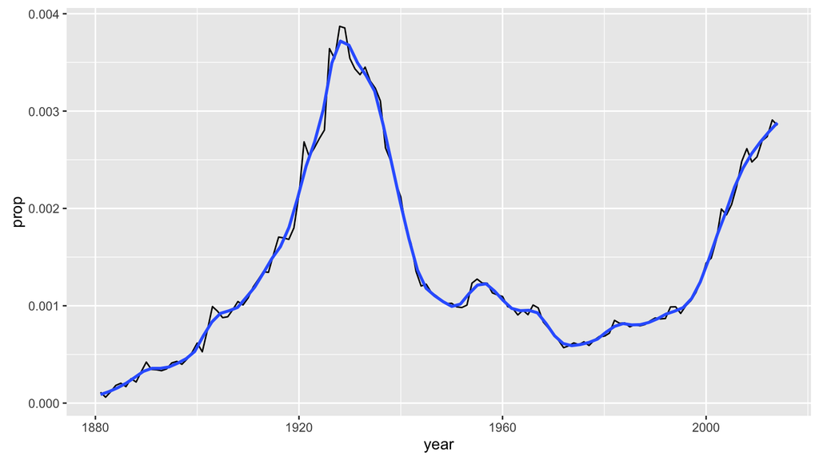

```r
female_audreys <- filter(babynames, name=="Audrey" & sex=="F")
ggplot(data=female_audreys, aes(x=year, y=prop)) +
  geom_line() +
  geom_smooth(se=FALSE, span=0.1)
```

- Set `span=10` in the last code block above. Does this appear to be a good smoother?

### Solution

In my opinion, `span=10` is a bit too coarse:

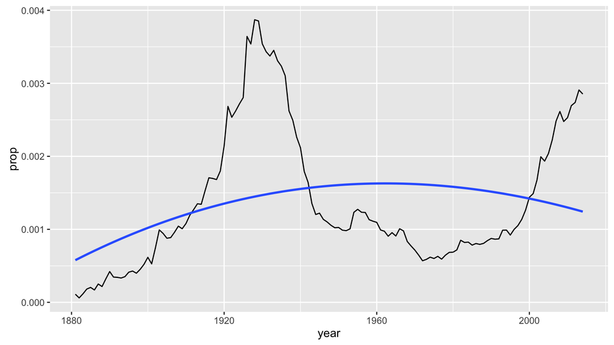

```r
ggplot(data=female_audreys, aes(x=year, y=prop)) +
  geom_line() +
  geom_smooth(se=FALSE, span=10)
```

But maybe `span=0.1` is TOO refined, i.e. not enough smoothing is happening. What about `span=1`:

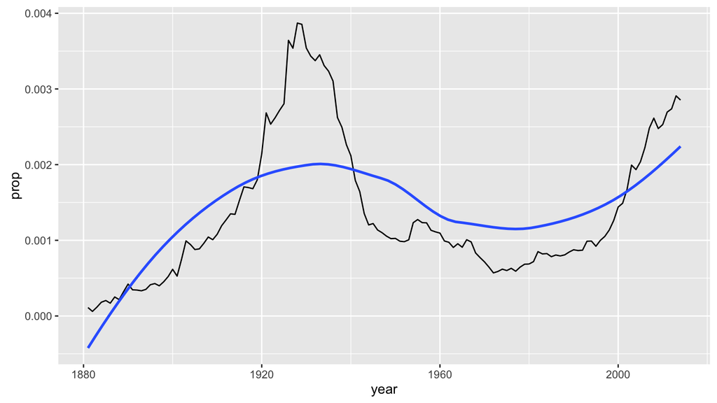

```r
ggplot(data=female_audreys, aes(x=year, y=prop)) +
  geom_line() +
  geom_smooth(se=FALSE, span=1)
```

## LC 4.10

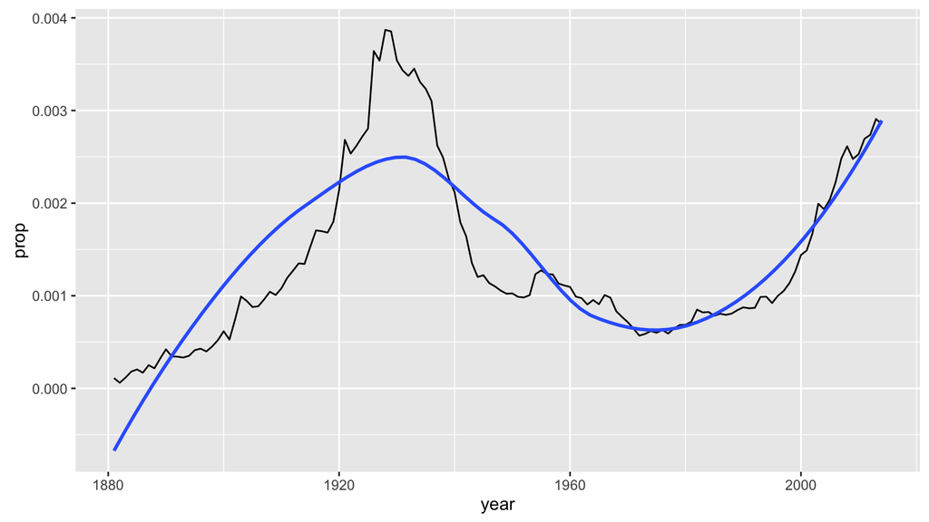

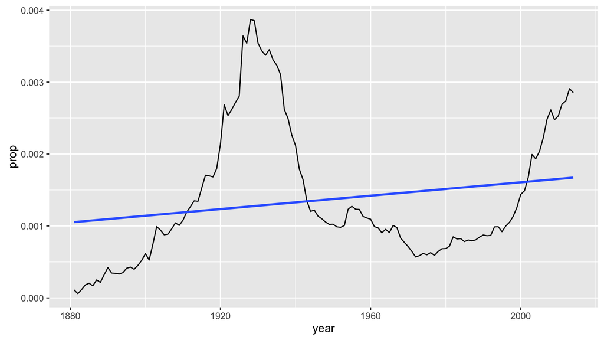

Do you think the earlier smoother or the regression line is a better way to pick out the “signal” (i.e. the trend) from the “noise” in the previous plot? Using this evidence, what do you think is a condition for a regression line to have “valid” interpretability?

### Solution

Hard to say.